# Pivoting datasets

## 7.3 Plotting

Finally, one of the data analysis tasks that is MOST hindered by wide formats is plotting. You may not yet have any prior knowledge of {ggplot} and how to plot so we will see the figures without going in depth with the code. What you need to remember is: many plots with with ggplot are also only possible with long-format data

Consider again the infant_deaths data `infant_deaths_long`. We will plot the number of deaths for Belgium per year:

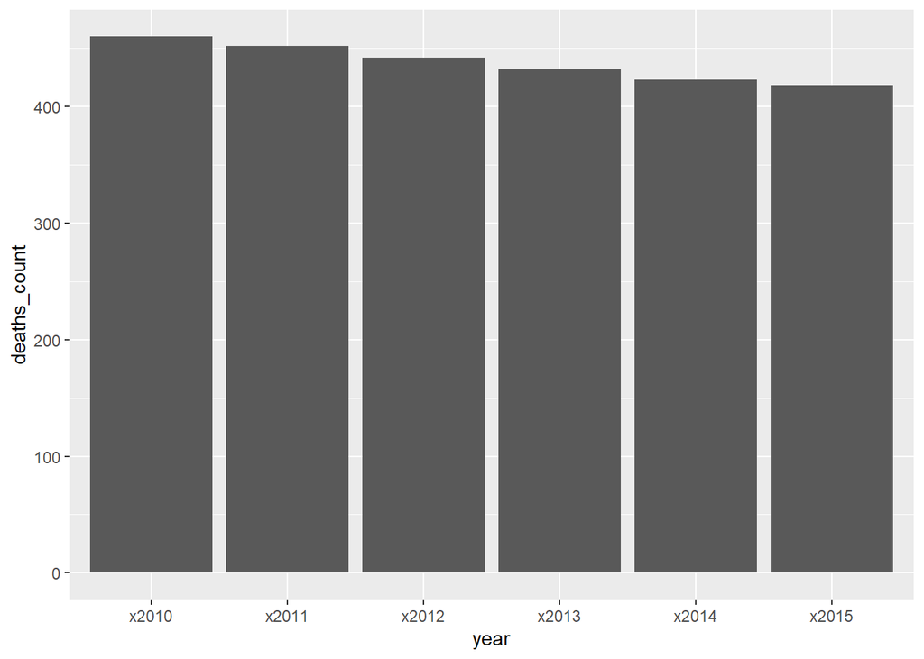

```r
infant_deaths_long %>%
  filter(country == "Belgium") %>%
  ggplot() +
  geom_col(aes(x = year, y = deaths_count))
```

The plotting works because we can give the variable `year` for the x-axis. In the long format, `year` is a variable variable of its own. In the wide format, each year is a column and your counts are a matrix, not a vector. Plots need vectors of data!

Another plot that would not be possible without a long format:

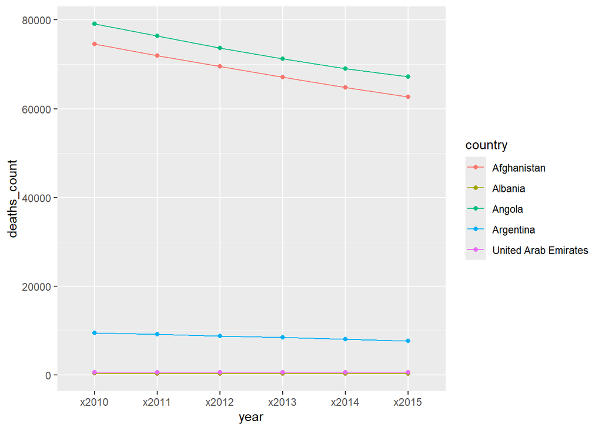

```r
infant_deaths_long %>%
  head(30) %>%
  ggplot(aes(x = year, y = deaths_count, group = country, color = country)) +
  geom_line() +
  geom_point()
```

Once again, the reason is the same, we need to tell the plot what to use as an x-axis and a y-axis and it is necessary to have these variables in their own column (as organized in the long format).

# Pivoting can be hard …

We have mostly looked at very simple examples here, but in the wild, you will run into not-so-neat situations. We strongly recommend some further reading of [this additional resource](https://tidyr.tidyverse.org/articles/pivot.html).

# Wrap Up !

You have now explored different datasets and how they are either in a long or wide format. In the end, it’s just about how you present the information. Sometimes one format will be more convenient, and other times another could be best. Now, you are no longer limited by the format of your data: don’t like it? change it !

# Contributors

The following team members contributed to this lesson:

- [KENE DAVID NWOSU](https://thegraphcourses.org/members/kendavidn/)  
  Data analyst, the GRAPH Network

  Passionate about world improvement
- [LAURE VANCAUWENBERGHE](https://thegraphcourses.org/members/lolovanco)  
  Data analyst, the GRAPH Network

  A firm believer in science for good, striving to ally programming, health and education